# Facet-Wrapped Histograms

## Project Focus and Setup

The goal is to create histogram plots for each factor level for a given response. In this case, I’m setting up two normal curves with offset sample means $\bar{x} = \pm2$.

```r
knitr::opts_chunk$set(message = FALSE, warning = FALSE)
# set up libraries
library(tidyverse)   # for plots and pipes
library(broom)       # for tidy statistics
library(knitr)       # for tables
library(gridExtra)   # for table formatting

# create a sample dataset of two normal curves with given classes
samples <- data.frame(val = rnorm(100, 2,2), pos = ("Righties")) %>%
  rbind(data.frame(val = rnorm(100, -2,1), pos = ("Lefties")) )

kable(samples[c(1:5,101:105),])
```

|  | val | pos |
| --- | --- | --- |
| 1 | -0.4461621 | Righties |
| 2 | 4.9468652 | Righties |
| 3 | 2.0302205 | Righties |
| 4 | 2.1729867 | Righties |
| 5 | 0.4780823 | Righties |
| 101 | -2.0371159 | Lefties |
| 102 | -1.1282932 | Lefties |
| 103 | -2.3974321 | Lefties |
| 104 | 0.2315765 | Lefties |
| 105 | -2.7981518 | Lefties |

We want to prepare summary statistics for as a visual annotation as well. We have a couple of “out of the box” options through the use of `summary` and the like, or we can build our own.

```r
#
# create generic statistical summary
samples %>%
  select_if(is.numeric)  %>%
  map(~tidy(summary(.x))) %>%  # compute tidy summary of each var
  do.call(rbind, .) -> stats   # bind list elements into df

kable(stats)
```

|  | minimum | q1 | median | mean | q3 | maximum |
| --- | --- | --- | --- | --- | --- | --- |
| val | -4.869436 | -2.060368 | -0.6535846 | -0.0454781 | 2.045927 | 6.177621 |

```r
#
# create a custom summary, in this case, just the mean and sd
summary_stats <- samples %>%
  group_by(pos) %>%
  summarize_at(vars(val),
             funs(Mean = mean, SD = sd))

summary_stats[,2:3] <-  round(summary_stats[,2:3],2)

kable(summary_stats)
```

| pos | Mean | SD |
| --- | --- | --- |
| Righties | 1.94 | 2.10 |
| Lefties | -2.03 | 1.07 |

## Visualization

The plots will be completed with ggplot, which is well suited for both html and pdf formats.

`geom_histogram`: creates histogram, plotting feature values against their frequencies

`geom_density`: smooths the histogram into a density plot, with y-axis as the relative frequency for a point

`geom_vline`: vertical line, in this case used to create a mean line

`gghighlight`: great way to show our data compared to the relative spread. Creates a “shadow” of the overall distribution.

`facet_grid`: breaks visuals into individual figures by feature.

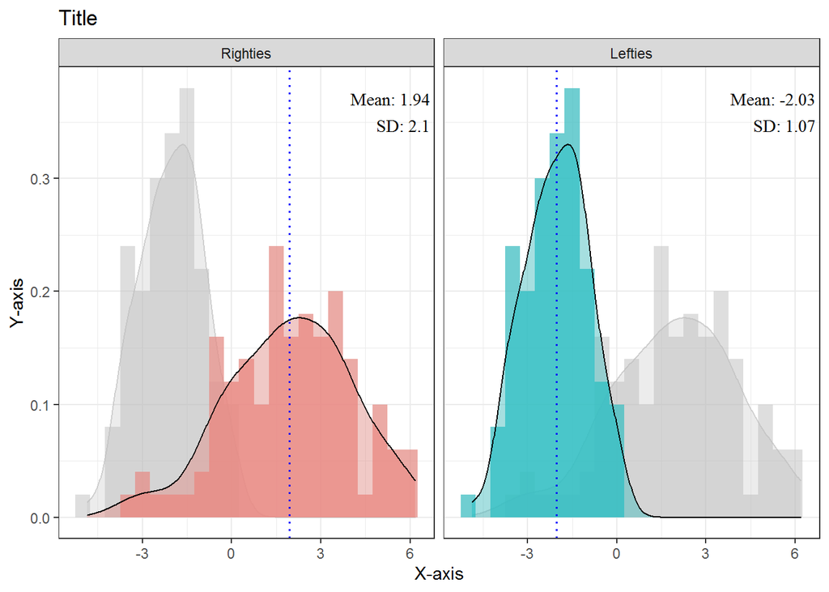

```r
#
# Create our visualization

#install.packages("gghighlight")

ggplot(samples, aes(x=val,fill=pos)) +
  # Graphs
  geom_histogram(aes(y=..density..),binwidth=.5, alpha=.5, position="identity") +
  geom_density(alpha=.3) +
  gghighlight::gghighlight()+


  # Mean line
  geom_vline(data = summary_stats, mapping = aes(xintercept = Mean), linetype="dotted",
              color = "blue", size=0.7) +

  # One figure per class
  facet_grid(.~pos, scales = "fixed")+

  #Labels
  ggtitle("Title")+
  xlab("X-axis") +
  ylab("Y-axis")+

  # Annotations
  geom_text(data=summary_stats,
             inherit.aes=FALSE,
             aes(vjust="inward", hjust = "inward",
                 x = Inf, y = Inf, family = "serif",
                 label=paste("\nMean:",Mean,"\nSD:",SD, "\n"))) +


  # Overall Theme
  theme_bw()
```